# Decision Trees & Random Forest in Python

Here we are taking a dataset that has a classification problem of doing the prediction.

```python
import numpy as np
import pandas as pd
import matplotlib.pyplot as plt
```

```python
# Import Dataset here..

disease = pd.read_csv("~/downloads/Python Bootcamp for ML/15-Decision-Trees-and-Random-Forests/kyphosis.csv")
```

```python
# Check the dataset

print(disease.head())
print("\n")
print("Dataset Length:: ", len(disease))
print("\n")
print("Dataset Shape:: ", disease.shape)
```

```
  Kyphosis  Age  Number  Start
0   absent   71       3      5
1   absent  158       3     14
2  present  128       4      5
3   absent    2       5      1
4   absent    1       4     15


Dataset Length::  81


Dataset Shape::  (81, 4)
```

```python
disease.info() #Checking the structure of the dataset
```

```
<class 'pandas.core.frame.DataFrame'>
RangeIndex: 81 entries, 0 to 80
Data columns (total 4 columns):
Kyphosis    81 non-null object
Age         81 non-null int64
Number      81 non-null int64
Start       81 non-null int64
dtypes: int64(3), object(1)
memory usage: 2.6+ KB
```

```python
# Lets Create some visualization such as pairplot
import seaborn as sns
```

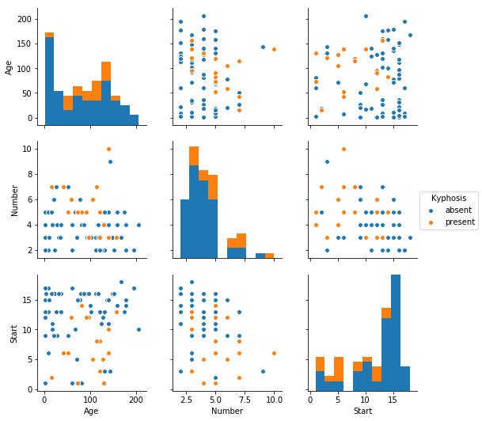

```python
sns.pairplot(disease, hue = "Kyphosis")
```

```python
# Identifying X and Y...
X = disease.drop("Kyphosis", axis=1)
Y = disease["Kyphosis"]
```

```python
# Split the data in train and test
from sklearn.cross_validation import train_test_split
X_train, X_test, Y_train, Y_test = train_test_split(X, Y, test_size = 0.3)

print(X_train.head())
print("\n")
print(Y_train.head())
print("\n")
print(X_test.head())
```

```
    Age  Number  Start
49  177       2     14
39   91       5     12
33  112       3     16
47  131       5     13
15    1       3     16


49     absent
39    present
33     absent
47     absent
15     absent
Name: Kyphosis, dtype: object


    Age  Number  Start
14  168       3     18
7    37       3     16
36    1       3      9
38   20       6      9
59  102       3     13
```

```python
# Decision Trees
from sklearn.tree import DecisionTreeClassifier
regressor = DecisionTreeClassifier()
```

```python
regressor.fit(X_train, Y_train)
```

```
DecisionTreeClassifier(class_weight=None, criterion='gini', max_depth=None,
            max_features=None, max_leaf_nodes=None,
            min_impurity_decrease=0.0, min_impurity_split=None,
            min_samples_leaf=1, min_samples_split=2,
            min_weight_fraction_leaf=0.0, presort=False, random_state=None,
            splitter='best')
```

```python
predictions = regressor.predict(X_test)
```

```python
from sklearn.metrics import classification_report, confusion_matrix
```

```python
print(confusion_matrix(Y_test, predictions))
print("\n")
print(classification_report(Y_test, predictions))
```

```
[[19  4]
 [ 0  2]]


             precision    recall  f1-score   support

     absent       1.00      0.83      0.90        23
    present       0.33      1.00      0.50         2

avg / total       0.95      0.84      0.87        25
```

```python
# Random Forest
from sklearn.ensemble import RandomForestClassifier
rfclassifiers = RandomForestClassifier(n_estimators = 2000)
```

```python
rfclassifiers.fit(X_train, Y_train)
predictions_rf = rfclassifiers.predict(X_test)
```

```python
print(confusion_matrix(Y_test, predictions_rf))
print("\n")
print(classification_report(Y_test, predictions_rf))
```

```
[[20  3]
 [ 0  2]]


             precision    recall  f1-score   support

     absent       1.00      0.87      0.93        23
    present       0.40      1.00      0.57         2

avg / total       0.95      0.88      0.90        25
```

# What is Precision Recall, F1 Score and Support

The precision is the ratio tp / (tp + fp) where tp is the number of true positives and fp the number of false positives. The precision is intuitively the ability of the classifier not to label as positive a sample that is negative.

The recall is the ratio tp / (tp + fn) where tp is the number of true positives and fn the number of false negatives. The recall is intuitively the ability of the classifier to find all the positive samples.

The F-beta score can be interpreted as a weighted harmonic mean of the precision and recall, where an F-beta score reaches its best value at 1 and worst score at 0.

The F-beta score weights recall more than precision by a factor of beta. beta == 1.0 means recall and precision are equally important.

The support is the number of occurrences of each class in y_true.